# report_editable_api

Podíl odpovědi za oddělení

Podíl odpovědi za firmu

Výsledky

Já a rozvoj - Spíše ano srovnání dle oddělení

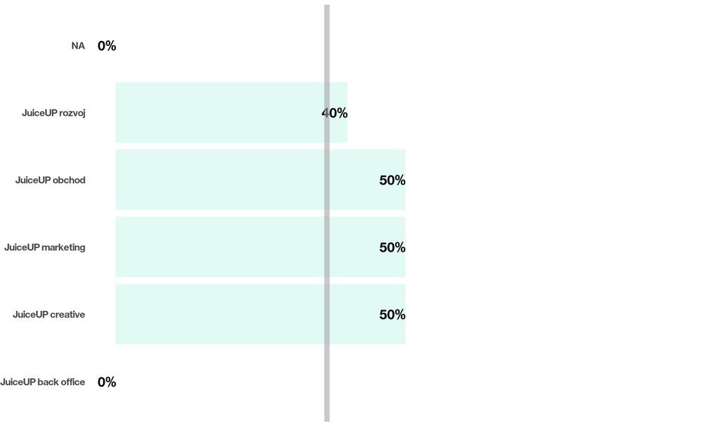

Legenda

Podíl odpovědi za oddělení

Podíl odpovědi za firmu

Výsledky

Já a firma - Spíše ano srovnání dle oddělení

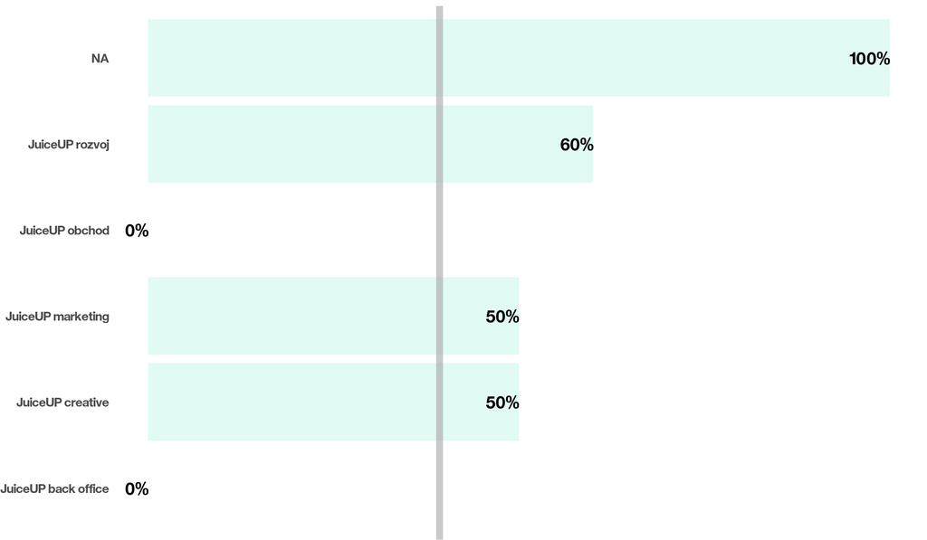

Legenda

Podíl odpovědi za oddělení

Podíl odpovědi za firmu

Výsledky

Já a výkon - Spíše ano srovnání dle oddělení

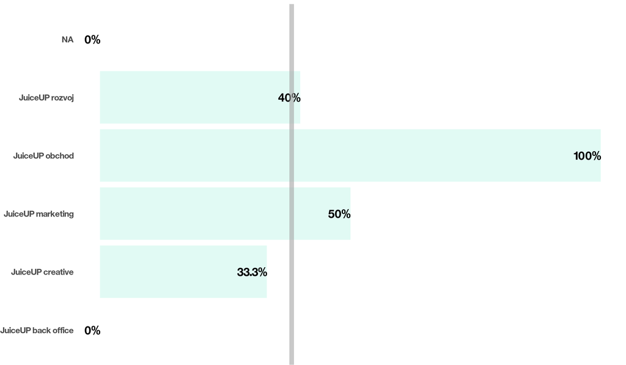

Legenda

Podíl odpovědi za oddělení

Podíl odpovědi za firmu

Výsledky

Já a tým - Nemohu se rozhodnout srovnání dle oddělení

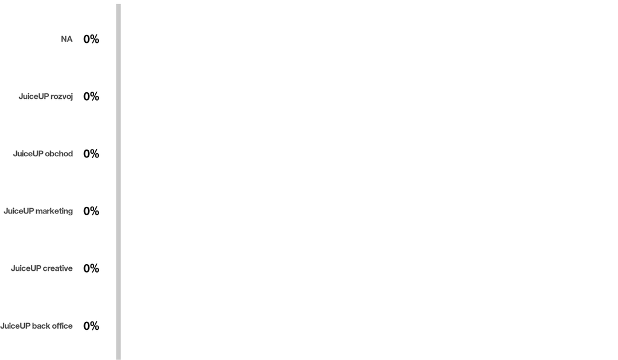

Legenda

Podíl odpovědi za oddělení

Podíl odpovědi za firmu

Výsledky

Já a vedoucí - Nemohu se rozhodnout srovnání dle oddělení

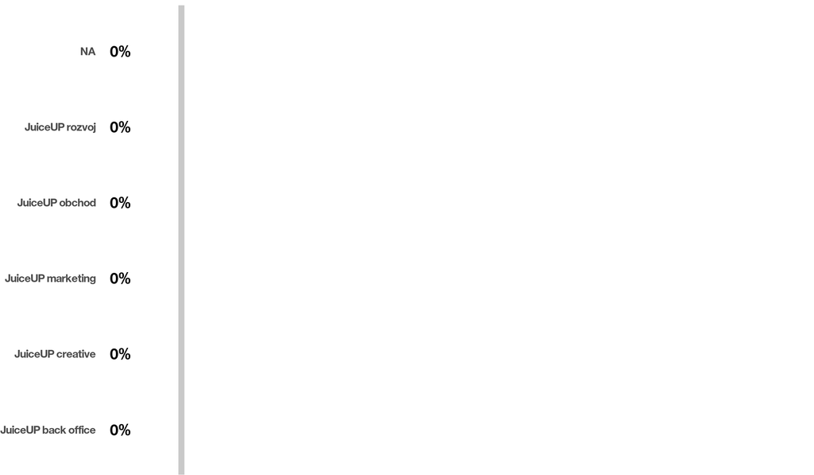

Legenda

Podíl odpovědi za oddělení

Podíl odpovědi za firmu

Výsledky

Směřování JuiceUP - Nemohu se rozhodnout srovnání dle oddělení

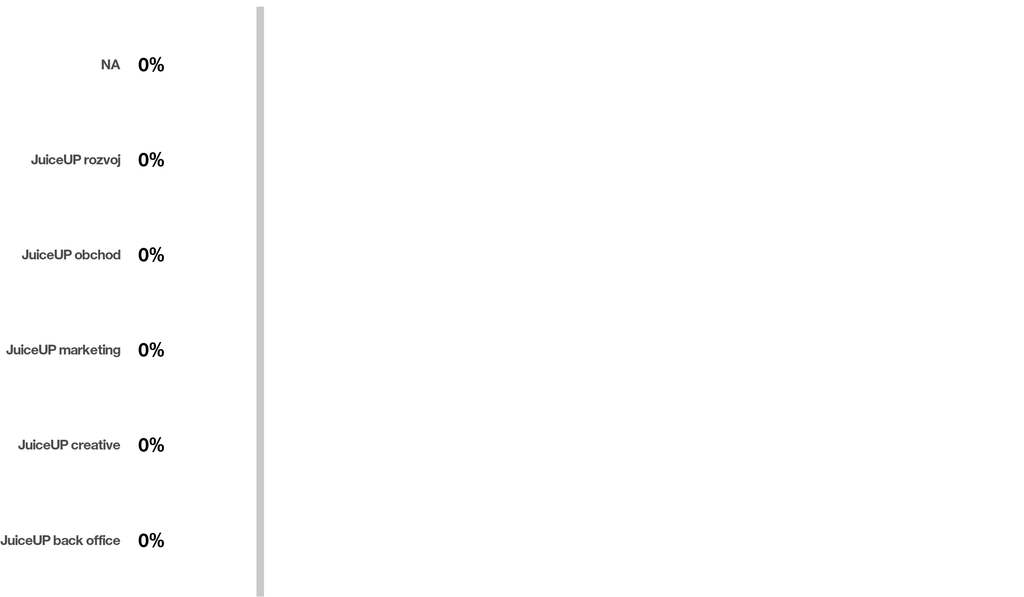

Legenda

Podíl odpovědi za oddělení

Podíl odpovědi za firmu

Výsledky

Já a rozvoj - Nemohu se rozhodnout srovnání dle oddělení

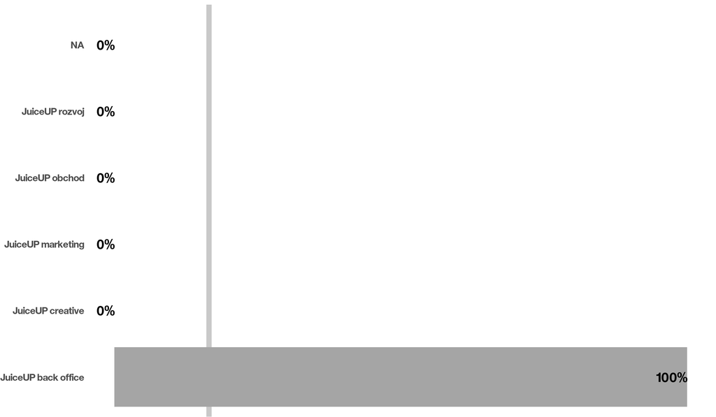

Legenda

Podíl odpovědi za oddělení

Podíl odpovědi za firmu

Výsledky

Já a firma - Nemohu se rozhodnout srovnání dle oddělení

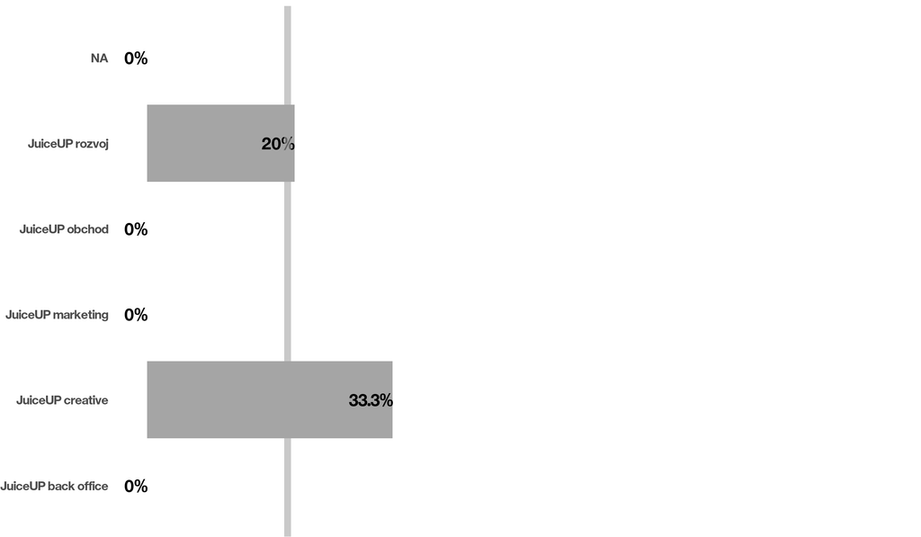

Legenda

Podíl odpovědi za oddělení

Podíl odpovědi za firmu

Výsledky

Já a výkon - Nemohu se rozhodnout srovnání dle oddělení

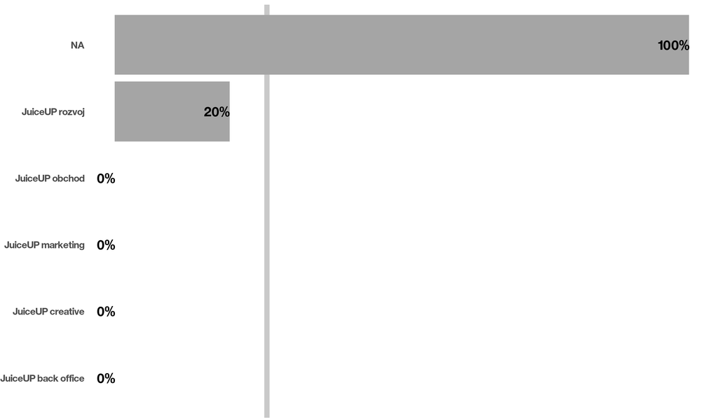

Legenda

Podíl odpovědi za oddělení

Podíl odpovědi za firmu

Výsledky

Já a tým - Spíše ne srovnání dle oddělení

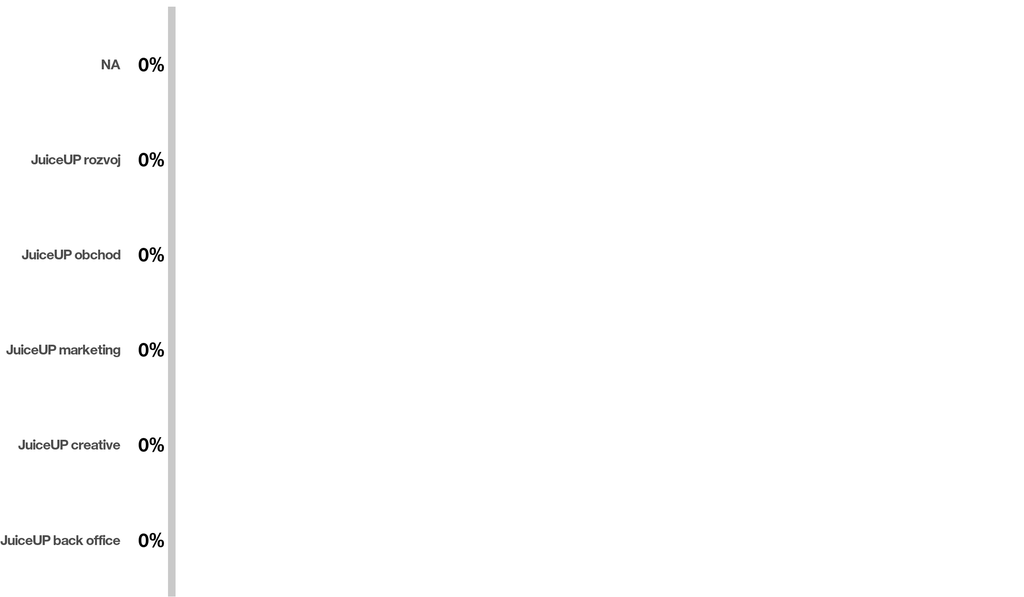

Legenda

Podíl odpovědi za oddělení

Podíl odpovědi za firmu

Legenda

Podíl odpovědi za oddělení

Podíl odpovědi za firmu

Výsledky

Směřování JuiceUP - Spíše ne srovnání dle oddělení

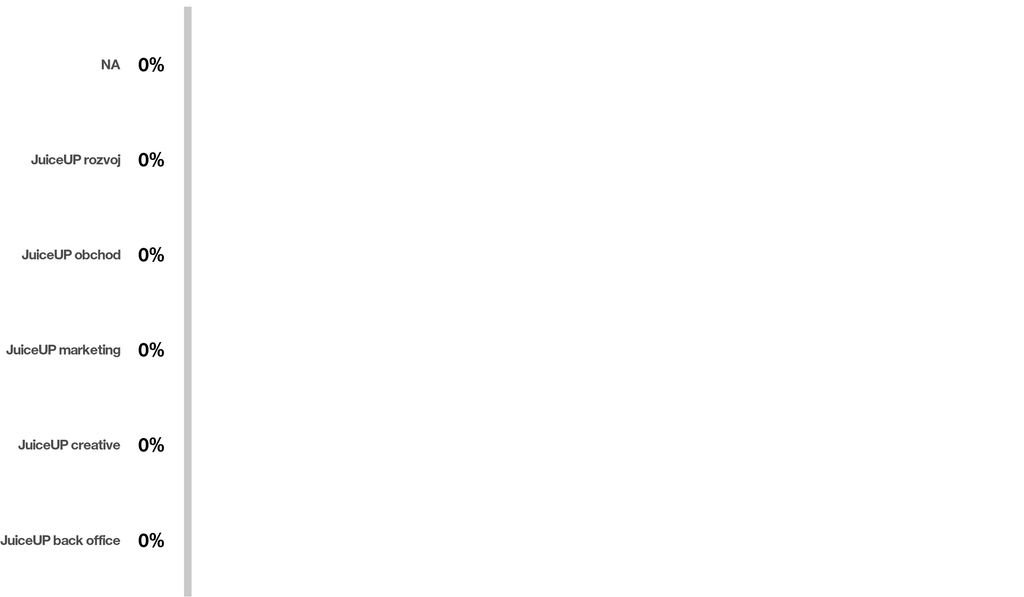

Legenda

Podíl odpovědi za oddělení

Podíl odpovědi za firmu

Výsledky

Já a rozvoj - Spíše ne srovnání dle oddělení

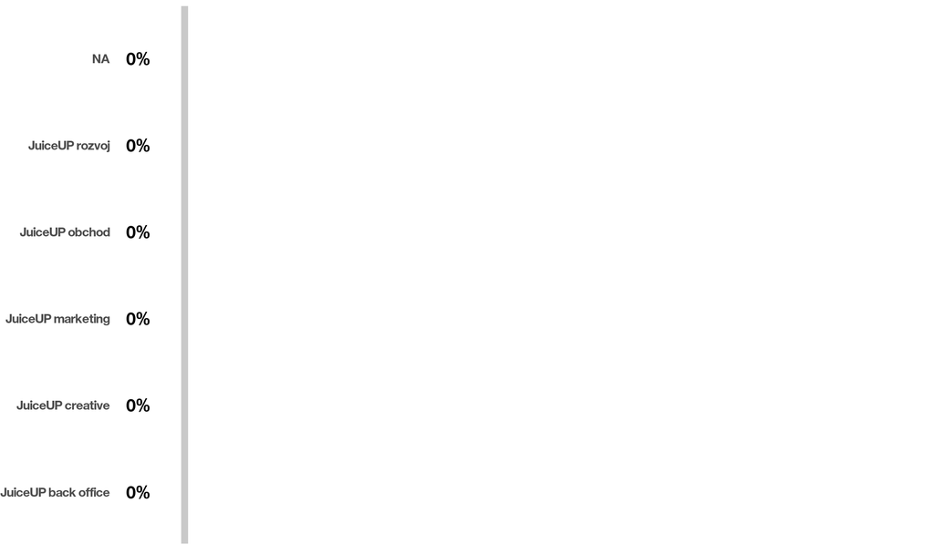

Legenda

Podíl odpovědi za oddělení

Podíl odpovědi za firmu

Výsledky

Já a firma - Spíše ne srovnání dle oddělení

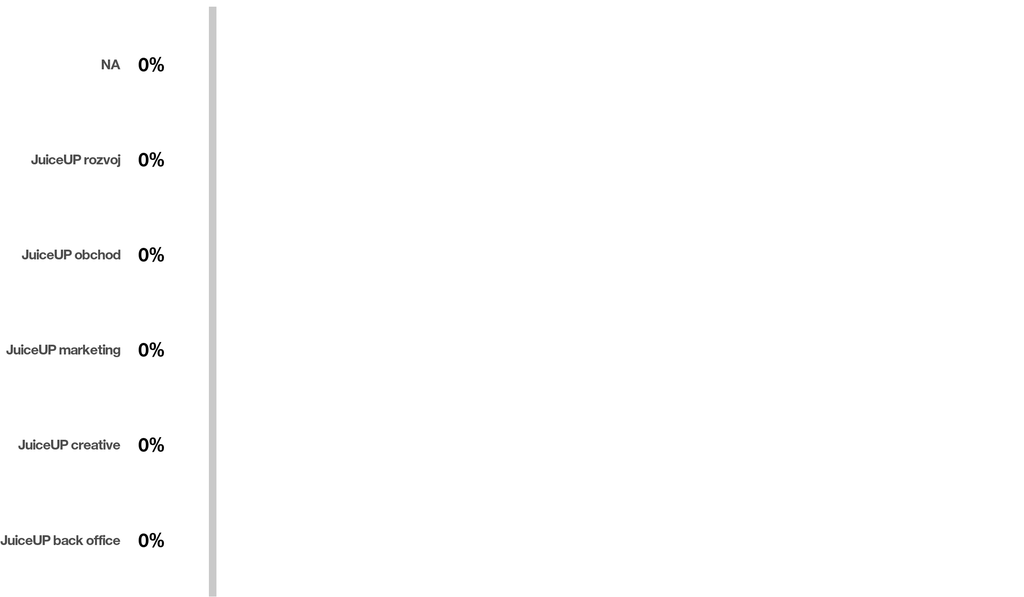

Legenda

Podíl odpovědi za oddělení

Podíl odpovědi za firmu

Výsledky

Já a výkon - Spíše ne srovnání dle oddělení

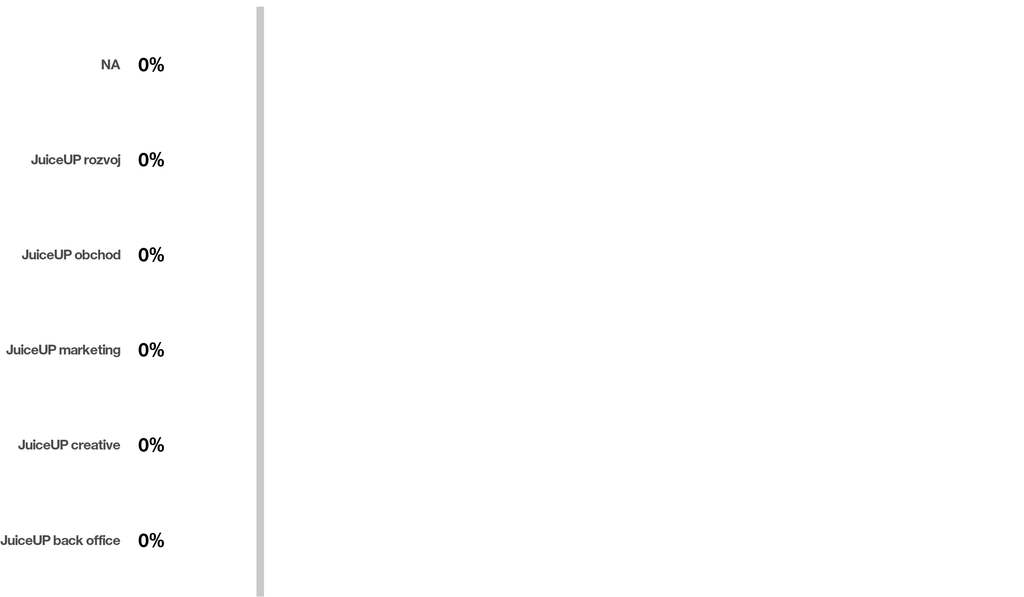

Legenda

Podíl odpovědi za oddělení

Podíl odpovědi za firmu

Legenda

Podíl odpovědi za oddělení

Podíl odpovědi za firmu

Legenda

Podíl odpovědi za oddělení

Podíl odpovědi za firmu

Legenda

Podíl odpovědi za oddělení

Podíl odpovědi za firmu

Výsledky

Já a rozvoj - Určitě ne srovnání dle oddělení

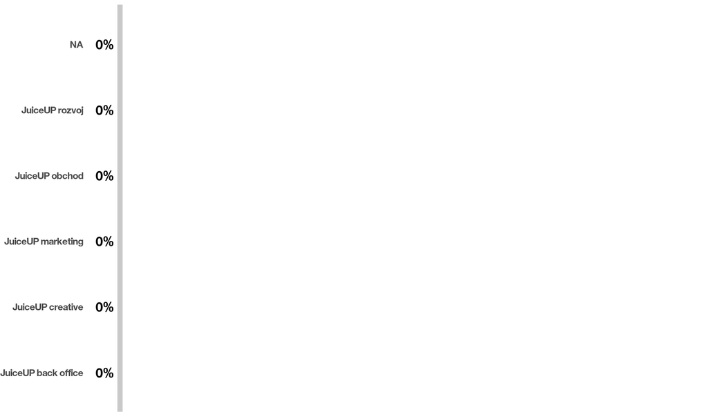

Legenda

Podíl odpovědi za oddělení

Podíl odpovědi za firmu

Legenda

Podíl odpovědi za oddělení

Podíl odpovědi za firmu

Výsledky

Já a výkon - Určitě ne srovnání dle oddělení

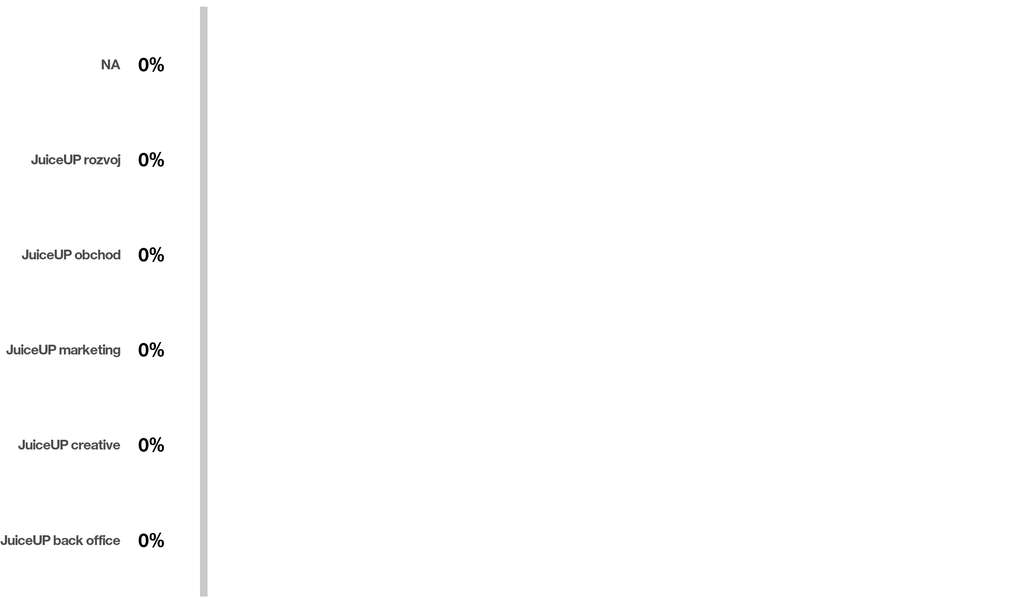

Legenda

Podíl odpovědi za oddělení

Podíl odpovědi za firmu